# P8105_HW6_ah4028

Austin Hsin

2023-11-28

## Problem 2

First, we will import the NOAA weather data provided by the homework document.

```r
#Importing NOAA Weather dataframe
weather_df =
  rnoaa::meteo_pull_monitors(
    c("USW00094728"),
    var = c("PRCP", "TMIN", "TMAX"),
    date_min = "2022-01-01",
    date_max = "2022-12-31") |>
  mutate(
    name = recode(id, USW00094728 = "CentralPark_NY"),
    tmin = tmin / 10,
    tmax = tmax / 10) |>
  select(name, id, everything())
```

Next, we will bootstrap our linear model of tmax = tmin + prcp and estimate r^2 and log(β^1 ∗ β^2) from the samples.

```r
#Bootstrapping weather_model dataframe
weather_model_df <-
  modelr::bootstrap(weather_df, n = 5000) |> #5000 samples
  mutate(
    models = map(strap, \(weather_df) lm(tmax ~ tmin + prcp, data = weather_df)), #linear model of tmax
    results = map(models, broom::tidy),
    model_glance = map(models, broom::glance)) |> #fitted regression statistics, specifically for r^2
  select(-strap, -models) |> #removing unnecessary variables
  unnest(results, model_glance) |>
  select(.id, term, estimate, r.squared) |> #selecting relevant variables
  pivot_wider(names_from = term,
              values_from = estimate) |>
  mutate(beta_calc = tmin + prcp) #log(β^1∗β^2) calculation
```

Next, we will calculate the 95% confidence intervals for r^2 and log(β^1 ∗ β^2).

```r
#95% Confidence Interval for r^2
weather_model_df |>
  summarize(
    r_sq_ci_lower = quantile(r.squared, 0.025),
    r_sq_ci_upper = quantile(r.squared, 0.975))
```

```
## # A tibble: 1 × 2
##   r_sq_ci_lower r_sq_ci_upper
##           <dbl>         <dbl>
## 1         0.888         0.940
```

```r
#log(β^1∗β^2) and 95% confidence interval
weather_model_df |>
  summarize(
    beta_ci_lower = quantile(beta_calc, 0.025),
    beta_ci_upper = quantile(beta_calc, 0.975))
```

```
## # A tibble: 1 × 2
##   beta_ci_lower beta_ci_upper
##           <dbl>         <dbl>
## 1         0.979          1.04
```

Finally, we will plot the distribution of the estimates.

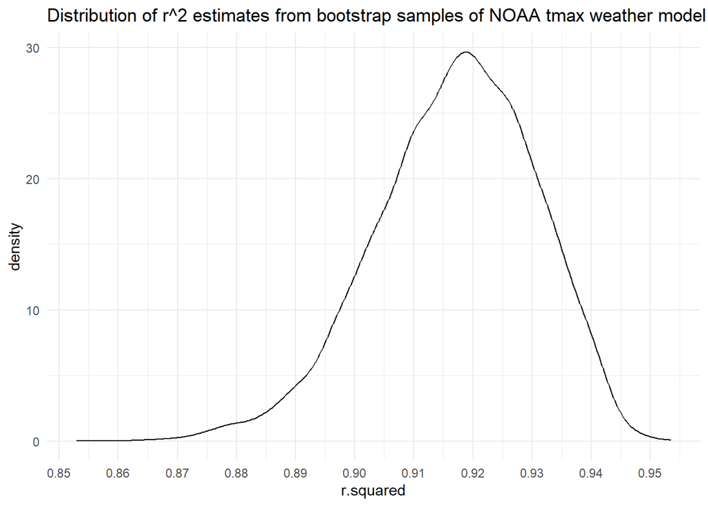

```r
#r^2 distribution
weather_model_df |>
  ggplot(aes(x = r.squared)) + geom_density() +
  labs(title = "Distribution of r^2 estimates from bootstrap samples of NOAA tmax weather model") + #title
  scale_x_continuous(n.breaks = 10) #ensuring adequate x axis breaks
```

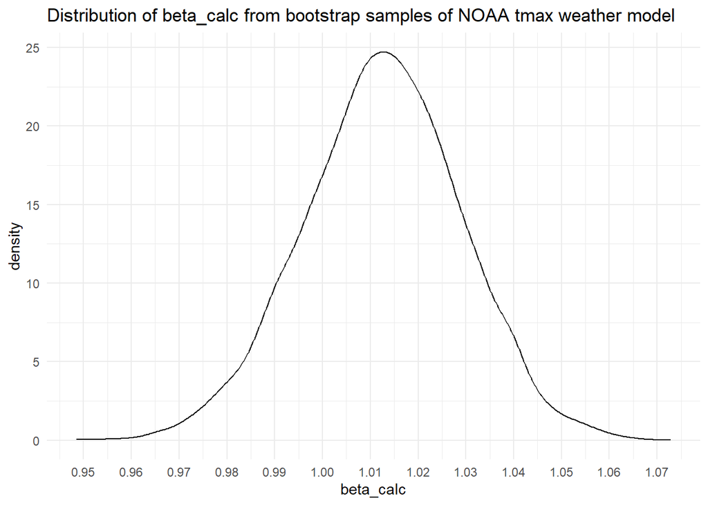

```r
#log(β^1∗β^2) distribution
weather_model_df |>
  ggplot(aes(x = beta_calc)) + geom_density() +
  labs(title = "Distribution of beta_calc from bootstrap samples of NOAA tmax weather model") + #title
  scale_x_continuous(n.breaks = 11) #ensuring adequate x axis breaks
```

## Problem 3

First, we will import and tidy the `birthweight.csv` data.

```r
#Importing birthweight.csv
bwt_df = read_csv("./data/birthweight.csv",
                          col_names = TRUE, #keeping column names
                          col_types = "fnnnnnnnnfnnnnnnnnnnn") |> #setting column types
  janitor::clean_names()
```

Next, we will propose a model for newborn birthweight, using some of the variables from `birthweight_df`, and subsequently produce a residuals vs fit plot.

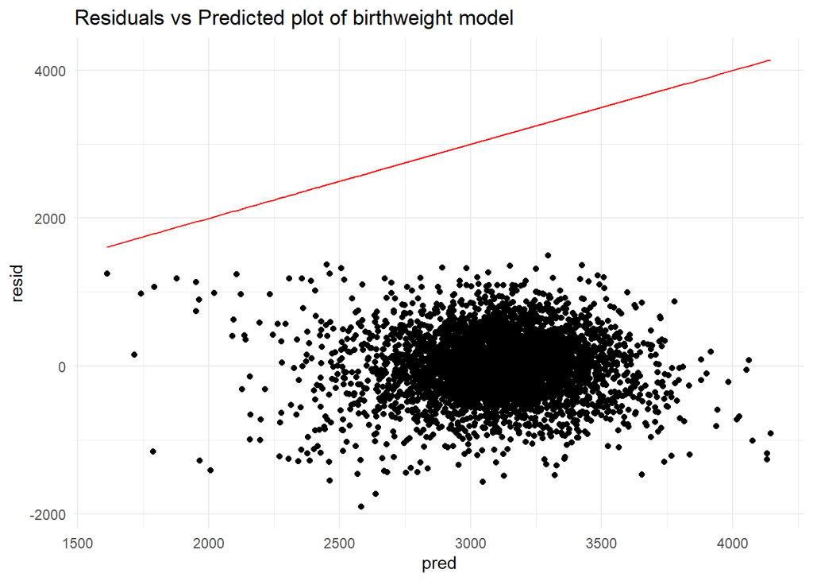

```r
#Proposed bwt linear model
bwt_model = lm(bwt ~ gaweeks + mheight + momage + delwt + parity + wtgain + smoken + fincome, data = bwt_df)

#Residuals vs Predicted plot
bwt_df |>
  modelr::add_residuals(bwt_model) |>
  modelr::add_predictions(bwt_model) |>
  ggplot(aes(x = pred, y = resid)) +
  geom_point() +
  geom_line(aes(y = pred), color = "red") +
  labs(title = "Residuals vs Predicted plot of birthweight model")
```

With regards to modeling, I primarily included mother attributes, specifically `gaweeks`, `mheight`, `momage`, `delwt`, `parity`, and `wtgain`, from prior healthcare knowledge as well as `smoken` and `fincome` as external attributes that are documented determinants. However, from the residuals vs predicted plot, it initially looks like the linear model is not very good given the clustering of values below the predicted line.

Finally, we will cross validate the proposed birthweight model against two other proposed models.

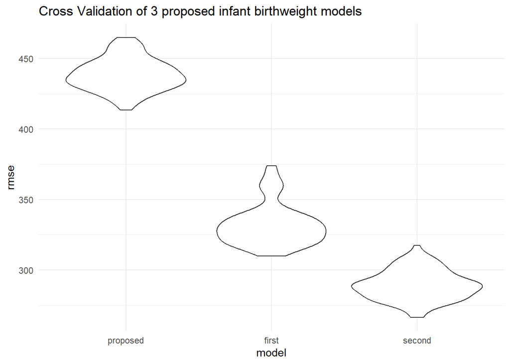

```r
#Creating cross validation dataframe
cv_df = crossv_mc(bwt_df, 100)

#Creating training and testing datasets
cv_df = cv_df |>
  mutate(train = map(train, as_tibble),
         test = map(test, as_tibble))

#Fitting models and obtaining RMSEs
cv_df = cv_df |>
  mutate(proposed_mod = map(train, \(df) lm(bwt ~ gaweeks + mheight + momage + delwt + parity + wtgain + smoken + fincome, data = df)),
         first_mod = map(train, \(df) lm(bwt ~ blength + gaweeks, data = df)),
         second_mod = map(train, \(df) lm(bwt ~ bhead + blength + babysex + bhead * blength + bhead * babysex + blength * babysex + bhead * blength * babysex, data = df))) |>
  mutate(
    rmse_proposed = map2_dbl(proposed_mod, test, \(mod, df) rmse(model = mod, data = df)),
    rmse_first = map2_dbl(first_mod, test, \(mod,df) rmse(model = mod, data = df)),
    rmse_second = map2_dbl(second_mod, test, \(mod,df) rmse(model = mod, data = df)))

#Plotting RMSE values for all three proposed models
cv_df |>
  select(starts_with("rmse")) |>
  pivot_longer(
    everything(),
    names_to = "model",
    values_to = "rmse",
    names_prefix = "rmse_") |>
  mutate(model = fct_inorder(model)) |>
  ggplot(aes(x = model, y = rmse)) +
  geom_violin() +
  labs(title = "Cross Validation of 3 proposed infant birthweight models")
```

From our cross validation plots, we can see that the proposed model of `bhead`, `blength`, and `babysex` and all possible interactions has the best fit out of all three proposed models as it has the lowest rmse value. On the flip side, my proposed linear model of `gaweeks`, `mheight`, `momage`, `delwt`, `parity`, `wtgain`, `smoken`, and `fincome` has the highest rmse of the three and thereby has really bad fit.